# Reticulate-Python with R-NLP-Health and Wellness Classifier

Janis Corona

4/19/2020

This uses a previous python3 script inside R with reticulate to communicate python code within R. This will classify a wellness or health category based on it being one of either articles pulled from the internet on: physical therapy benefits, massage therapy benefits, chiropractic benefits, massage gun benefits, benefits of mental health services, cold stone therapy benefits, or cupping benefits. Then some ‘non professional’ google and twitter massage posts were added in to this selection to see how well the classifier could discriminate between one of the seven professional healthcare recommendations and a non-professional recommendation.

```r
# knitr::knit_engines$set(python = reticulate::eng_python)

library(reticulate)
conda_list(conda = "auto")
```

```
##           name                                                  python
## 1    Anaconda2                     C:\\Users\\m\\Anaconda2\\python.exe
## 2    djangoenv    C:\\Users\\m\\Anaconda2\\envs\\djangoenv\\python.exe
## 3     python36     C:\\Users\\m\\Anaconda2\\envs\\python36\\python.exe
## 4     python37     C:\\Users\\m\\Anaconda2\\envs\\python37\\python.exe
## 5 r-reticulate C:\\Users\\m\\Anaconda2\\envs\\r-reticulate\\python.exe
```

Without having my python IDE, Anaconda, open in the console I want to use the python36 environment, all the environments in Anaconda for python are listed above.

```r
use_condaenv(condaenv = "python36")
```

```python
import pandas as pd
import matplotlib.pyplot as plt
from textblob import TextBlob
import sklearn
import numpy as np
from sklearn.feature_extraction.text import CountVectorizer
from sklearn.naive_bayes import MultinomialNB
from sklearn.metrics import classification_report, f1_score, accuracy_score, confusion_matrix

np.random.seed(47)
```

The following data table will not show in your Rstudio environment, but python inside your python IDE will store the table.

```python
modalities = pd.read_csv('benefitsContraindications2.csv', encoding = 'unicode_escape')
```

```python
print(modalities.head())
```

```
##                                             Document  ... InternetSearch
## 0  Chiropractic adjustments and treatments serve ...  ...            NaN
## 1  \r\nUnitedHealthcare Combats Opioid Crisis wit...  ...            NaN
## 2   The Safety of Chiropractic Adjustments\r\nBy ...  ...            NaN
## 3  Advanced Chiropractic Relief: 8 Key Benefits o...  ...            NaN
## 4  Heading to the spa can be a pampering treat, b...  ...         google
##
## [5 rows x 4 columns]
```

```python
print(modalities.tail())
```

```
##                                              Document  ... InternetSearch
## 76  she looks like she got those tits from those c...  ...            NaN
## 77  Whens the last time you gave your man a back ...  ...            NaN
## 78  \r\nRed heart\r\n + \r\nClockwise rightwards a...  ...            NaN
## 79  \r\nDoes full body massage include private par...  ...         google
## 80  So I'm meeting with my CPA yesterday.  Great g...  ...         google
##
## [5 rows x 4 columns]
```

```python
print(modalities.shape)
```

```
## (81, 4)
```

```python
print(modalities.columns)
```

```
## Index(['Document', 'Source', 'Topic', 'InternetSearch'], dtype='object')
```

```python
import regex
def preprocessor(text):
    text = regex.sub('<[^>]*>', '', text)
    emoticons = regex.findall('(?::|;|=)(?:-)?(?:\)|\(|D|P)', text)
    text = regex.sub('[\W]+', ' ', text.lower()) +\
        ' '.join(emoticons).replace('-', '')
    return text
```

```python
modalities.tail()
```

```
##                                              Document  ... InternetSearch
## 76  she looks like she got those tits from those c...  ...            NaN
## 77  Whens the last time you gave your man a back ...  ...            NaN
## 78  \r\nRed heart\r\n + \r\nClockwise rightwards a...  ...            NaN
## 79  \r\nDoes full body massage include private par...  ...         google
## 80  So I'm meeting with my CPA yesterday.  Great g...  ...         google
##
## [5 rows x 4 columns]
```

Reorder the observations so that they are mixed and not grouped together as they are in the original file.

```python
import numpy as np

modalities = modalities.reindex(np.random.permutation(modalities.index))

print(modalities.head())
```

```
##                                              Document  ... InternetSearch
## 70  lucy should experience the mindnumbing pleasur...  ...            NaN
## 25  \r\nThe Challenges and Benefits of Treatment f...  ...         google
## 14  What Are the Health Benefits of Massage?\r\n\r...  ...         google
## 40  \r\nWhat Is Cupping Therapy?And Should You Try...  ...         google
## 74               I could go for a nice Booty Massage!  ...            NaN
##
## [5 rows x 4 columns]
```

```python
print(modalities.tail())
```

```
##                                              Document  ... InternetSearch
## 72        I adore men who massage me all over my body  ...            NaN
## 8   BENEFITS OF MASSAGE\r\n\r\nYou know that post-...  ...         google
## 71  Hey twitter I'm looking for a lady to massage ...  ...            NaN
## 6   25 Reasons to Get a Massage\r\n\r\nNovember 5,...  ...         google
## 7   7 Benefits of Massage Therapy\r\n\r\nMassage t...  ...         google
##
## [5 rows x 4 columns]
```

```python
modalities.columns
```

```
## Index(['Document', 'Source', 'Topic', 'InternetSearch'], dtype='object')
```

```python
modalities.groupby('Topic').describe()
```

```
##                                 Document         ... InternetSearch
##                                    count unique  ...            top freq
## Topic                                            ...
## Not Professional                      16     16  ...         google    2
## chiropractic benefits                  8      8  ...         google    4
## cold stone benefits                   10     10  ...         google   10
## cupping benefits                      10     10  ...         google   10
## massage benefits                      12     12  ...         google   12
## massage gun benefits                  10     10  ...         google   10
## mental health services benefits        6      6  ...         google    6
## physical therapy benefits              9      9  ...         google    9
##
## [8 rows x 12 columns]
```

```python
modalities['length'] = modalities['Document'].map(lambda text: len(text))
print(modalities.head())
```

```
##                                              Document  ... length
## 70  lucy should experience the mindnumbing pleasur...  ...     55
## 25  \r\nThe Challenges and Benefits of Treatment f...  ...   5425
## 14  What Are the Health Benefits of Massage?\r\n\r...  ...   1820
## 40  \r\nWhat Is Cupping Therapy?And Should You Try...  ...   5471
## 74               I could go for a nice Booty Massage!  ...     36
##
## [5 rows x 5 columns]
```

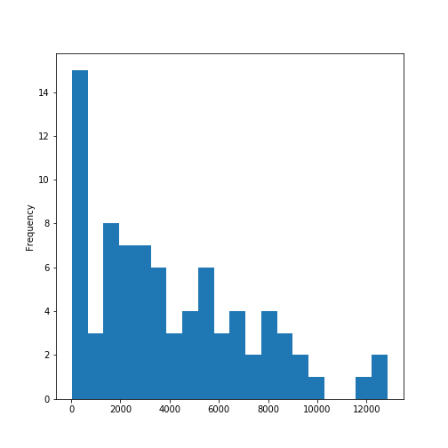

```python
#%matplotlib inline
modalities.length.plot(bins=20, kind='hist')
plt.show()
```

```python
modalities.length.describe()
```

```
## count       81.000000
## mean      3992.592593
## std       3238.213565
## min         27.000000
## 25%       1452.000000
## 50%       3337.000000
## 75%       6125.000000
## max      12846.000000
## Name: length, dtype: float64
```

```python
print(list(modalities.Document[modalities.length > 4000].index))
```

```
## [25, 40, 42, 38, 29, 5, 49, 39, 1, 16, 30, 58, 26, 44, 3, 54, 27, 22, 35, 17, 46, 2, 34, 28, 9, 53, 41, 50, 55, 45, 59, 23, 51, 7]
```

```python
print(list(modalities.Topic[modalities.length > 4000]))
```

```
## ['mental health services benefits', 'cupping benefits', 'cupping benefits', 'cupping benefits', 'mental health services benefits', 'massage benefits', 'massage gun benefits', 'cupping benefits', 'chiropractic benefits', 'physical therapy benefits', 'mental health services benefits', 'cold stone b…
```

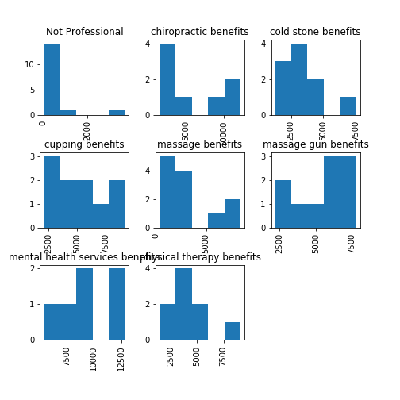

```python
modalities.hist(column='length', by='Topic', bins=5)


plt.show()
```

```python
def split_into_tokens(review):

    #review = unicode(review, 'iso-8859-1')# in python 3 the default of str() previously python2 as unicode() is utf-8
    return TextBlob(review).words
```

```python
modalities.Document.head().apply(split_into_tokens)
```

```
## 70    [lucy, should, experience, the, mindnumbing, p...
## 25    [The, Challenges, and, Benefits, of, Treatment...
## 14    [What, Are, the, Health, Benefits, of, Massage...
## 40    [What, Is, Cupping, Therapy, And, Should, You,...
## 74         [I, could, go, for, a, nice, Booty, Massage]
## Name: Document, dtype: object
```

```python
TextBlob("hello world, how is it going?").tags  # list of (word, POS) pairs
```

```
## [('hello', 'JJ'), ('world', 'NN'), ('how', 'WRB'), ('is', 'VBZ'), ('it', 'PRP'), ('going', 'VBG')]
```

```python
import nltk
nltk.download('stopwords')
```

```
## True
##
```

```python
from nltk.corpus import stopwords

stop = stopwords.words('english')
stop = stop + [u'a',u'b',u'c',u'd',u'e',u'f',u'g',u'h',u'i',u'j',u'k',u'l',u'm',u'n',u'o',u'p',u'q',u'r',u's',u't',u'v',u'w',u'x',u'y',u'z']
```

```python
def split_into_lemmas(review):
    #review = unicode(review, 'iso-8859-1')
    review = review.lower()
    #review = unicode(review, 'utf8').lower()
    #review = str(review).lower()
    words = TextBlob(review).words
    # for each word, take its "base form" = lemma
    return [word.lemma for word in words if word not in stop]

modalities.Document.head().apply(split_into_lemmas)
```

```
## 70    [lucy, experience, mindnumbing, pleasure, mass...
## 25    [challenge, benefit, treatment, mental, health...
## 14    [health, benefit, massage, many, type, massage...
## 40    [cupping, therapy, try, 're, definitely, going...
## 74                    [could, go, nice, booty, massage]
## Name: Document, dtype: object
```

```python
bow_transformer = CountVectorizer(analyzer=split_into_lemmas).fit(modalities['Document'])
print(len(bow_transformer.vocabulary_))
```

```
## 4926
```

```python
modality4 = modalities['Document'][42]
print(modality4)
```

```
## What to know about cupping therapy
##
##     Does it work?
##     Pain relief
##     Skin conditions
##     Sports recovery
##     Side effects and risks
##     Takeaway
##
## There is some evidence to suggest that cupping therapy may be beneficial for certain health conditions. However, research into cupping therapy tends to be low-quality. More studies are necessary to understand how cupping therapy works, if it works, and in what situations it may help.
##
## Cupping therapy is a traditional Chinese and Middle Eastern practice that people use to treat a variety of conditions.
##
## It involves placing cups at certain points on a person?s skin. A practitioner creates suction in the cups, which pulls against a person?s skin.
##
## Cupping can either be dry or wet. Wet cupping involves puncturing the skin before starting the suction, which removes some of the person?s blood during the procedure.
##
## Cupping typically leaves round bruises on a person?s skin, where their blood vessels burst after exposure to the procedure?s suction effects.
## Does it work?
## Cupping therapy may help increase or decrease blood flow.
##
## According to a study paper in the journal PLoS One, cupping practitioners claim that it works by creating hyperemia or hemostasis around a person?s skin. This means that it either increases or decreases a person?s blood flow under the cups.
##
## Cupping also has links to acupoints on a person?s body, which are central to the practice of acupuncture.
##
## Many doctors consider cupping therapy a complementary therapy, which means that many do not recognize it as part of Western medicine. This does not mean that it is not effective, however.
##
## Complementary therapies with supporting research may be an addition to Western medicine. However, as the National Center for Complementary and Integrative Health (NCCIH) note, there is not yet enough high-quality research to prove cupping?s effectiveness.
##
## Scientists have linked cupping therapy with a variety of health benefits, although there needs to be more research to determine whether it is effective as a treatment.
## Pain relief
##
## People frequently cite cupping therapy as a form of pain relief. However, while there is some evidence for its effectiveness, scientists need to conduct more high-quality studies to demonstrate this fully.
##
## For example, a study paper in the journal Evidence-based Complementary and Alternative Medicine found some evidence to suggest that cupping may reduce pain. However, its authors note that there were limits to the quality of the studies that showed this.
##
## A meta-analysis that appears in the journal Revista Latina-Americano De Enfermagem claims that there may be evidence for cupping being effective in treating back pain. However, again, the researchers note that most studies were low-quality, and that there is a need for more standardization in fut…
##
## One study paper in the journal BMJ Open came to a similar conclusion for the effectiveness of cupping for neck pain. The researchers note that there is a need for better-quality studies to determine whether cupping therapy is truly effective.
## Medical News Today Newsletter
```

[output cut: 35 more lines]

```
##     nausea
##     insomnia
##
## Due to the poor quality of studies investigating cupping, it is difficult to know how common these side effects are.
##
## If a person has any of these side effects following cupping therapy, they should speak to a medical professional. Some people may have health conditions, such as problems with blood clotting, that making cupping less than ideal.
## Takeaway
##
## There is some evidence to suggest that cupping therapy may be able to help a person with certain health issues. However, there are not enough high-quality studies to support this.
##
## To understand whether cupping therapy is effective, how it works, and what issues it is best for, scientists need to conduct and publish more high-quality research.
##
## If a person finds that cupping therapy relieves their pain or helps their health in another way, and if they do not experience any adverse side effects, cupping may be a very good choice. However, some therapies have better evidence for their effectiveness. Doctors may advise that people consider…
##
## A person may choose to use cupping therapy alongside better-evidenced therapies. If this is the case, it is important that they let a medical professional know.
```

```python
bow4 = bow_transformer.transform([modality4])
print(bow4)
```

```
##   (0, 186)   1
##   (0, 212)   3
##   (0, 233)   1
##   (0, 248)   1
##   (0, 250)   2
##   (0, 260)   1
##   (0, 289)   1
##   (0, 294)   1
##   (0, 353)   1
##   (0, 356)   2
##   (0, 362)   2
##   (0, 364)   1
##   (0, 386)   1
##   (0, 406)   1
##   (0, 422)   1
##   (0, 430)   2
##   (0, 437)   1
##   (0, 453)   1
##   (0, 460)   1
##   (0, 500)   1
##   (0, 519)   1
##   (0, 544)   1
##   (0, 597)   1
##   (0, 598)   1
##   (0, 606)   2
##   :  :
##   (0, 4443)  21
##   (0, 4494)  1
##   (0, 4500)  1
##   (0, 4517)  1
##   (0, 4538)  1
##   (0, 4557)  1
##   (0, 4560)  2
##   (0, 4561)  1
##   (0, 4583)  1
##   (0, 4608)  1
##   (0, 4609)  1
##   (0, 4634)  2
##   (0, 4685)  2
##   (0, 4689)  1
##   (0, 4709)  2
##   (0, 4719)  1
##   (0, 4729)  1
##   (0, 4791)  1
##   (0, 4822)  2
##   (0, 4823)  3
##   (0, 4830)  3
##   (0, 4861)  6
##   (0, 4870)  1
##   (0, 4900)  1
##   (0, 4916)  1
```

```python
modalities_bow = bow_transformer.transform(modalities['Document'])
print('sparse matrix shape:', modalities_bow.shape)
```

```
## sparse matrix shape: (81, 4926)
```

```python
print('number of non-zeros:', modalities_bow.nnz)
```

```
## number of non-zeros: 17030
```

```python
print('sparsity: %.2f%%' % (100.0 * modalities_bow.nnz / (modalities_bow.shape[0] * modalities_bow.shape[1])))
```

```
## sparsity: 4.27%
```

```python
modalities_bow
```

```
## <81x4926 sparse matrix of type '<class 'numpy.int64'>'
##  with 17030 stored elements in Compressed Sparse Row format>
```

Indexing is different in python compared to R. Python includes zero and when indicating a slice, the last value is ignored, so only up to the value. So it is used to slice, so that the next can start and include that number up to the empty slice which indicates the last value.

```python
# Split/splice into training ~ 80% and testing ~ 20%
modalities_bow_train = modalities_bow[:65]
modalities_bow_test = modalities_bow[65:]
modalities_sentiment_train = modalities['Topic'][:65]
modalities_sentiment_test = modalities['Topic'][65:]

print(modalities_bow_train.shape)
```

```
## (65, 4926)
```

```python
print(modalities_bow_test.shape)
```

```
## (16, 4926)
```

```python
modalities_sentiment = MultinomialNB().fit(modalities_bow_train, modalities_sentiment_train)
```

```python
print('predicted:', modalities_sentiment.predict(bow4)[0])
```

```
## predicted: cupping benefits
```

```python
print('expected:', modalities.Topic[42])
```

```
## expected: cupping benefits
```

```python
predictions = modalities_sentiment.predict(modalities_bow_test)
print(predictions)
```

```
## ['cupping benefits' 'massage gun benefits' 'massage benefits'
##  'massage gun benefits' 'massage benefits' 'massage gun benefits'
##  'cold stone benefits' 'massage gun benefits' 'cold stone benefits'
##  'physical therapy benefits' 'massage gun benefits' 'massage gun benefits'
##  'massage benefits' 'massage benefits' 'massage benefits'
##  'massage benefits']
```

```python
print('accuracy', accuracy_score(modalities_sentiment_test, predictions))
```

```
## accuracy 0.625
```

```python
print('confusion matrix\n', confusion_matrix(modalities_sentiment_test, predictions))
```

```
## confusion matrix
##  [[0 1 0 2 2 0]
##  [0 1 0 1 0 0]
##  [0 0 1 0 0 0]
##  [0 0 0 3 0 0]
##  [0 0 0 0 4 0]
##  [0 0 0 0 0 1]]
```

```python
print('(row=expected, col=predicted)')
```

```
## (row=expected, col=predicted)
```

```python
print(classification_report(modalities_sentiment_test, predictions))
```

```
##                            precision    recall  f1-score   support
##
##          Not Professional       0.00      0.00      0.00         5
##       cold stone benefits       0.50      0.50      0.50         2
##          cupping benefits       1.00      1.00      1.00         1
##          massage benefits       0.50      1.00      0.67         3
##      massage gun benefits       0.67      1.00      0.80         4
## physical therapy benefits       1.00      1.00      1.00         1
##
##                  accuracy                           0.62        16
##                 macro avg       0.61      0.75      0.66        16
##              weighted avg       0.45      0.62      0.51        16
##
##
```

From the above, precision accounts for type 1 errors (how many real negatives classified as positives-False Positives: TP/(TP+FP)) and type 2 errors (how many real posiives classified as negatives-False Negatives: TP/(TP+FN)) are part of recall.

```python
modalitiesu = modalities.Topic.unique()
mus = np.sort(modalitiesu)
mus
```

```
## array(['Not Professional', 'chiropractic benefits', 'cold stone benefits',
##        'cupping benefits', 'massage benefits', 'massage gun benefits',
##        'mental health services benefits', 'physical therapy benefits'],
##       dtype=object)
```

The ‘Not Professional’ class is not getting sorted alphabetically with the others, this could be because it is capitalized. This effects the order of probability readings.

```python
def predict_modality(new_review):
    new_sample = bow_transformer.transform([new_review])
    pr = np.around(modalities_sentiment.predict_proba(new_sample),2)
    print(new_review,'\n\n', pr)
    print('\n\nThe respective order:\n 0-Non Professional\n 1-chiropractic therapy\n 2-cold stone therapy\n 3-cupping therapy\n 4-massage therapy\n 5-massage gun therapy\n 6-mental health therapy\n 7-physical therapy\n\n')

    if (pr[0][0] == max(pr[0])):
        print('The max probability is Non-Professional services for this recommendation with ', pr[0][0]*100,'%')

    elif (pr[0][1] == max(pr[0])):
        print('The max probability is chiropractic therapy for this recommendation with ', pr[0][1]*100,'%')

    elif (pr[0][2] == max(pr[0])):
        print('The max probability is cold stone massage for this recommendation with ', pr[0][2]*100,'%')

    elif (pr[0][3] == max(pr[0])):
        print('The max probability is cupping therapy for this recommendation with ', pr[0][3]*100,'%')

    elif (pr[0][4] == max(pr[0])):
        print('The max probability is massage therapy for this recommendation with ', pr[0][4]*100,'%')

    elif (pr[0][5] == max(pr[0])):
        print('The max probability is massage gun therapy for this recommendation with ', pr[0][5]*100,'%')

    elif (pr[0][6] == max(pr[0])):
        print('The max probability is mental health therapy for this recommendation with ', pr[0][6]*100,'%')

    else:
        print('The max probability is physical therapy for this recommendation with ', pr[0][7]*100,'%')

    print('-----------------------------------------\n\n')
```

```python
predict_modality('Headaches, body sweats, depressed.')
```

```
## Headaches, body sweats, depressed.
##
##  [[0.03 0.35 0.07 0.02 0.49 0.01 0.01 0.01]]
##
##
## The respective order:
##  0-Non Professional
##  1-chiropractic therapy
##  2-cold stone therapy
##  3-cupping therapy
##  4-massage therapy
##  5-massage gun therapy
##  6-mental health therapy
##  7-physical therapy
##
##
## The max probability is massage therapy for this recommendation with  49.0 %
## -----------------------------------------
```

```python
predict_modality('sleepless, energy depraved, cold, tension')
```

```
## sleepless, energy depraved, cold, tension
##
##  [[0.   0.01 0.95 0.04 0.01 0.   0.   0.  ]]
##
##
## The respective order:
##  0-Non Professional
##  1-chiropractic therapy
##  2-cold stone therapy
##  3-cupping therapy
##  4-massage therapy
##  5-massage gun therapy
##  6-mental health therapy
##  7-physical therapy
##
##
## The max probability is cold stone massage for this recommendation with  95.0 %
## -----------------------------------------
```

```python
predict_modality('body aches from working out')
```

```
## body aches from working out
##
##  [[0.12 0.05 0.17 0.1  0.22 0.19 0.07 0.08]]
##
##
## The respective order:
##  0-Non Professional
##  1-chiropractic therapy
##  2-cold stone therapy
##  3-cupping therapy
##  4-massage therapy
##  5-massage gun therapy
##  6-mental health therapy
##  7-physical therapy
##
##
## The max probability is massage therapy for this recommendation with  22.0 %
## -----------------------------------------
```

```python
predict_modality('can\'t move my arm. stuck at home. worried about my neck.')
```

```
## can't move my arm. stuck at home. worried about my neck.
##
##  [[0.   0.37 0.02 0.03 0.29 0.11 0.   0.17]]
##
##
## The respective order:
##  0-Non Professional
##  1-chiropractic therapy
##  2-cold stone therapy
##  3-cupping therapy
##  4-massage therapy
##  5-massage gun therapy
##  6-mental health therapy
##  7-physical therapy
##
##
## The max probability is chiropractic therapy for this recommendation with  37.0 %
## -----------------------------------------
```

In the above user inputs, the one recommending cold stones when the user is cold, should be an error or contraindication, but we haven’t made that classification. The data would have to be separated into benefits and contraindications from each document internet searched on each modality. We could do this another time.

```python
predict_modality('breathing ragged, tired, headaches, dizzy, nausious ')
```

```
## breathing ragged, tired, headaches, dizzy, nausious
##
##  [[0.05 0.35 0.08 0.09 0.4  0.01 0.01 0.02]]
##
##
## The respective order:
##  0-Non Professional
##  1-chiropractic therapy
##  2-cold stone therapy
##  3-cupping therapy
##  4-massage therapy
##  5-massage gun therapy
##  6-mental health therapy
##  7-physical therapy
##
##
## The max probability is massage therapy for this recommendation with  40.0 %
## -----------------------------------------
```

The above should be under contraindications for massage, but we didn’t move that far. Those are listings of contraindications for massage in mentioning the dizzy, nausious, and breathing ragged. But we didn’t add in any medical professional services categories to our data to classify. We should do that later.

```python
predict_modality("relief from this pain. can't sleep. feet hurt. chills.")
```

```
## relief from this pain. can't sleep. feet hurt. chills.
##
##  [[0.   0.38 0.   0.03 0.49 0.01 0.   0.08]]
##
##
## The respective order:
##  0-Non Professional
##  1-chiropractic therapy
##  2-cold stone therapy
##  3-cupping therapy
##  4-massage therapy
##  5-massage gun therapy
##  6-mental health therapy
##  7-physical therapy
##
##
## The max probability is massage therapy for this recommendation with  49.0 %
## -----------------------------------------
```

```python
predict_modality('love this place better than others')
```

```
## love this place better than others
##
##  [[0.1  0.09 0.05 0.27 0.02 0.01 0.41 0.03]]
##
##
## The respective order:
##  0-Non Professional
##  1-chiropractic therapy
##  2-cold stone therapy
##  3-cupping therapy
##  4-massage therapy
##  5-massage gun therapy
##  6-mental health therapy
##  7-physical therapy
##
##
## The max probability is mental health therapy for this recommendation with  41.0 %
## -----------------------------------------
```

This user input is more like a review, and the documents other than the ‘Non Professional’ class were all online articles authored by professionals in the field of each category. The ‘Non Professional’ category had a 10% recommendation for this user input, just below cupping therapy at 27% and this mental health recommendation with 41%.

```python
predict_modality('massage guns and cupping are great for my post workout aches')
```

```
## massage guns and cupping are great for my post workout aches
##
##  [[0. 0. 0. 0. 0. 1. 0. 0.]]
##
##
## The respective order:
##  0-Non Professional
##  1-chiropractic therapy
##  2-cold stone therapy
##  3-cupping therapy
##  4-massage therapy
##  5-massage gun therapy
##  6-mental health therapy
##  7-physical therapy
##
##
## The max probability is massage gun therapy for this recommendation with  100.0 %
## -----------------------------------------
```

```python
predict_modality('sexy.fun.massage.Asian. pretty girls')
```

```
## sexy.fun.massage.Asian. pretty girls
##
##  [[0.5  0.04 0.15 0.05 0.13 0.04 0.03 0.06]]
##
##
## The respective order:
##  0-Non Professional
##  1-chiropractic therapy
##  2-cold stone therapy
##  3-cupping therapy
##  4-massage therapy
##  5-massage gun therapy
##  6-mental health therapy
##  7-physical therapy
##
##
## The max probability is Non-Professional services for this recommendation with  50.0 %
## -----------------------------------------
```

The above correctly classify as a non-professional services description. This is great, because when expecting to have legitimate healthcare requests, occasionally some scummy users slip in and want a service that isn’t provided. This could also be a recommended use for mental health services for addictions and similar. Although, the mental health documents said this user has a 3% probability compared to the other categories to recommend to this user. The next highest class recommeded was for cold stone massage, which is surprising. The ‘pretty’ and ‘fun’ could have been in the cold stone massage ads or when describing the modality and appearance of the marble stones.

```python
predict_modality('It looks like bruises on my back. Paranoid somebody will tease me about them. I feel better, but still some aches and pains.')
```

```
## It looks like bruises on my back. Paranoid somebody will tease me about them. I feel better, but still some aches and pains.
##
##  [[0.   0.05 0.   0.93 0.   0.01 0.   0.  ]]
##
##
## The respective order:
##  0-Non Professional
##  1-chiropractic therapy
##  2-cold stone therapy
##  3-cupping therapy
##  4-massage therapy
##  5-massage gun therapy
##  6-mental health therapy
##  7-physical therapy
##
##
## The max probability is cupping therapy for this recommendation with  93.0 %
## -----------------------------------------
```

```r
library(tidytext)
library(tm)
library(dplyr)
library(ggplot2)
library(tidyr)
library(wordcloud)
```

```r
modalities <- read.csv('benefitsContraindications2.csv',
                              sep=',', header=TRUE, na.strings=c('',' ','NA'))
```

```r
colnames(modalities)
```

```
## [1] "Document"       "Source"         "Topic"          "InternetSearch"
```

```r
modalities1 <- modalities[,c(1,3)]
head(modalities1)
```

[output not shown]

We are to make our data table into a dplyr tibble.

```r
text_df <- tibble(line=1:81, text=modalities1$Document,
                  Recommend=modalities1$Topic)
head(text_df)
```

```
## # A tibble: 6 x 3
##    line text                                                   Recommend
##   <int> <fct>                                                  <fct>
## 1     1 "Chiropractic adjustments and treatments serve the ne~ chiropractic ben~
## 2     2 "\nUnitedHealthcare Combats Opioid Crisis with Non-Op~ chiropractic ben~
## 3     3 " The Safety of Chiropractic Adjustments\nBy Lana Bar~ chiropractic ben~
## 4     4 "Advanced Chiropractic Relief: 8 Key Benefits of Chir~ chiropractic ben~
## 5     5 "Heading to the spa can be a pampering treat, but it ~ massage benefits
## 6     6 "Massage: Get in touch with its many benefits\n\nMass~ massage benefits
```

```r
text_df$text <- as.character(paste(text_df$text))

fills <- as.data.frame(c('of','the','a','an','in','by','it','as','or','go','goes','am','and','to'))
colnames(fills) <- 'fillers'

text_df0 <- text_df %>% unnest_tokens(bigram,text,token='ngrams',n=2) %>%
  separate(bigram, c('word1','word2'), sep=' ')

text_df01 <- anti_join(text_df0,fills, by=c("word1"="fillers"))
text_df02 <- anti_join(text_df01,fills, by=c("word2"="fillers"))

text_df02$bigram <- paste(text_df02$word1,text_df02$word2,sep=' ')
text_df03 <- text_df02[,-c(2:4)]

text_df1 <- text_df %>% unnest_tokens(bigram,text, token='ngrams',n=2)
text_df2 <- merge(text_df1,text_df03, by.x='bigram', by.y='bigram', all.y=FALSE)

text_df3 <- text_df2[,-4]
colnames(text_df3)[2] <- 'line'
head(text_df3,30)
```

```
##                                                                                     bigram
## 1   _______________________________________________________________________________ damkee
## 2    _______________________________________________________________________________ mebak
## 3  _______________________________________________________________________________ sylphim
## 4                                                                                      0 6
## 5                                                                               0 comments
## 6                                                                                  01 03pm
## 7                                                                                  02 2013
## 8                                                                                  02 2019
## 9                                                                                  02 2020
## 10                                                                           02 futuristic
## 11                                                                                   03 02
## 12                                                                                 03 2020
## 13                                                                                03pm edt
## 14                                                                                   04 30
```

[output cut: 47 more lines]

```r
text_df4 <- text_df3 %>% group_by(bigram) %>% count(bigram, sort=TRUE) %>% ungroup
head(text_df4,30)
```

```
## # A tibble: 30 x 2
##    bigram               n
##    <chr>            <int>
##  1 mental health    24964
##  2 physical therapy 11236
##  3 massage gun       9409
##  4 massage therapy   7921
##  5 massage guns      6241
##  6 if you            5776
##  7 can be            4900
##  8 can help          4900
##  9 stone massage     3249
## 10 you can           3136
## # ... with 20 more rows
```

The above shows all documents bigram occurences of word pairs.

We want the recommended modality or health care option for each category counts of bigrams.

```r
nonPro <- subset(text_df3, text_df3$Recommend=='Not Professional')
chiropractor <- subset(text_df3, text_df3$Recommend=='chiropractic benefits')
massage <- subset(text_df3, text_df3$Recommend=='massage benefits')
physicalTherapy <- subset(text_df3, text_df3$Recommend=='physical therapy benefits')
mental <- subset(text_df3, text_df3$Recommend=='mental health services benefits')
cupping <- subset(text_df3, text_df3$Recommend=='cupping benefits')
massageGun <- subset(text_df3, text_df3$Recommend=='massage gun benefits')
coldStone <- subset(text_df3, text_df3$Recommend=='cold stone benefits')
```

Group each category into bigram counts.

```r
nonPro2 <- nonPro %>% group_by(bigram) %>% count(bigram, sort=TRUE)
nonPro3 <- spread(nonPro2,bigram,n)
freqNonPro <- colSums(nonPro3)

chiropractor2 <- chiropractor %>% group_by(bigram) %>% count(bigram, sort=TRUE)
chiropractor3 <- spread(chiropractor2,bigram,n)
freqChiropractor <- colSums(chiropractor3)

massage2 <- massage %>% group_by(bigram) %>% count(bigram, sort=TRUE)
massage3 <- spread(massage2,bigram,n)
freqMassage <- colSums(massage3)

physical2 <- physicalTherapy %>% group_by(bigram) %>% count(bigram, sort=TRUE)
physical3 <- spread(physical2,bigram,n)
freqPhysical <- colSums(physical3)

mental2 <- mental %>% group_by(bigram) %>% count(bigram, sort=TRUE)
mental3 <- spread(mental2,bigram,n)
freqMental <- colSums(mental3)

cupping2 <- cupping %>% group_by(bigram) %>% count(bigram, sort=TRUE)
cupping3 <- spread(cupping2,bigram,n)
freqCupping <- colSums(cupping3)

massageGun2 <- massageGun %>% group_by(bigram) %>% count(bigram, sort=TRUE)
massageGun3 <- spread(massageGun2,bigram,n)
freqMassageGun <- colSums(massageGun3)

coldStone2 <- coldStone %>% group_by(bigram) %>% count(bigram, sort=TRUE)
coldStone3 <- spread(coldStone2,bigram,n)
freqColdStone <- colSums(coldStone3)
```

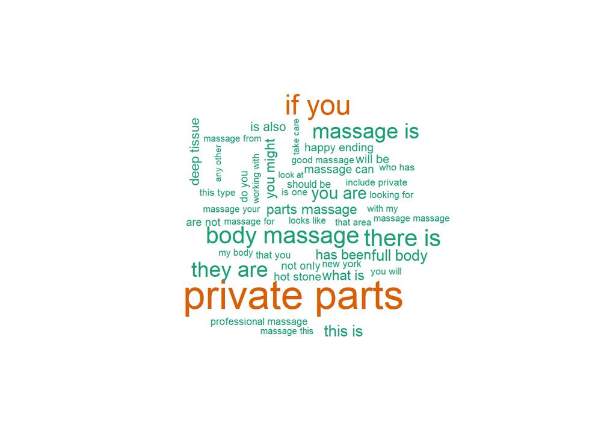

```r
wordcloud(names(freqNonPro), freqNonPro,
          min.freq=5,colors=brewer.pal(3,'Dark2'))
```

The above shows most bigrams or double word pairings in the non-professional services category.

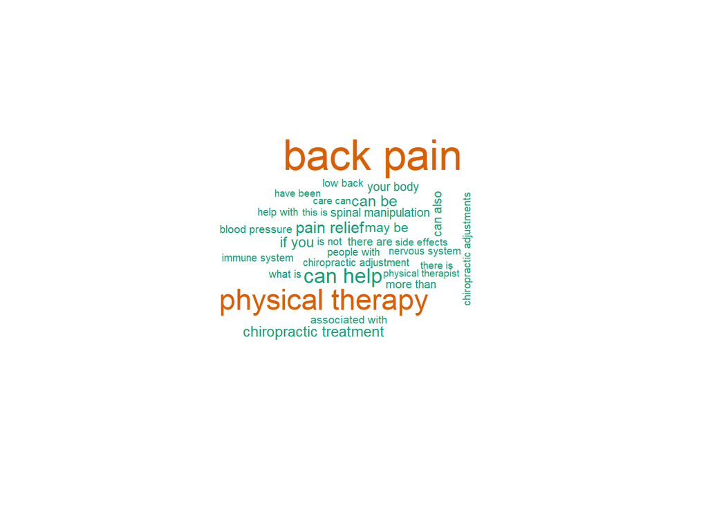

```r
wordcloud(names(freqChiropractor), freqChiropractor,
          min.freq=80,colors=brewer.pal(3,'Dark2'))
```

The above word cloud shows the top frequency bigram word pairs for chiropractic services.

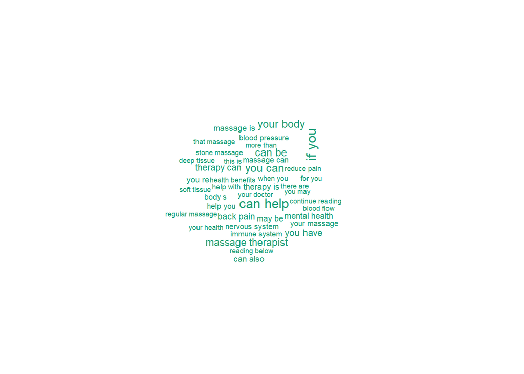

```r
wordcloud(names(freqMassage), freqMassage, min.freq=80,colors=brewer.pal(3,'Dark2'))
```

The above word cloud is for massage therapy services word pairs used most often.

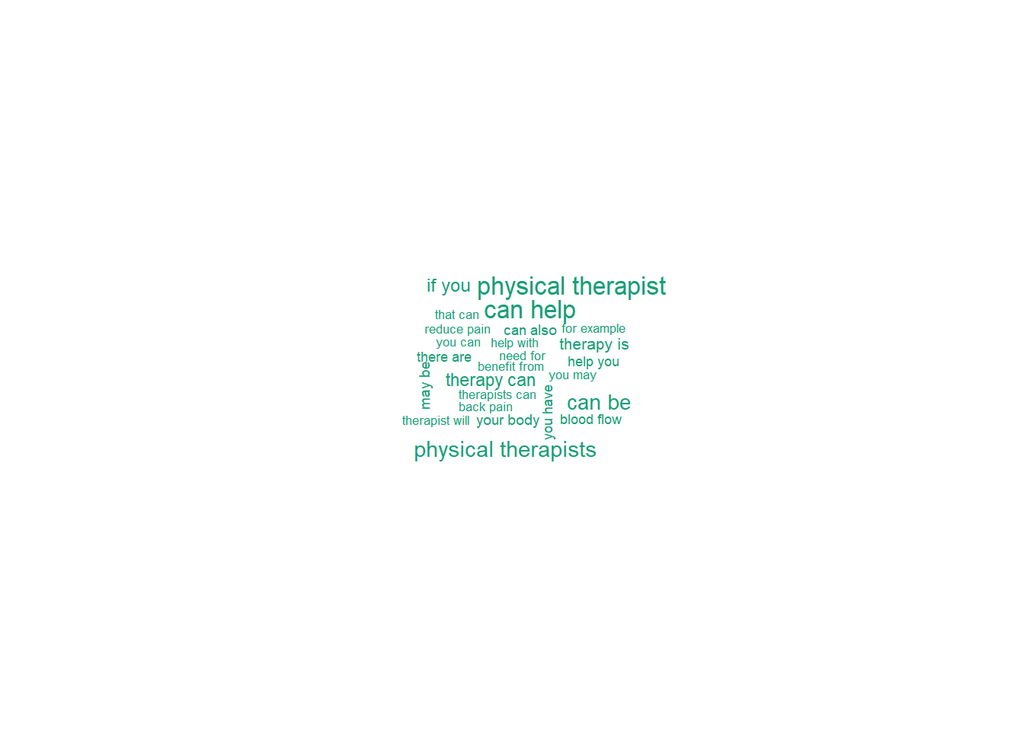

```r
wordcloud(names(freqPhysical), freqPhysical,
          min.freq=80,colors=brewer.pal(3,'Dark2'))
```

The above word cloud is the bigram word pairs used in physical therapy services documents in the data.

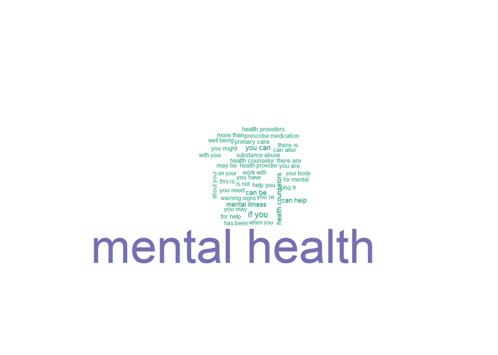

```r
wordcloud(names(freqMental), freqMental,
          min.freq=80,colors=brewer.pal(3,'Dark2'))
```

The above word cloud is for word pairs used frequently in mental health documents.

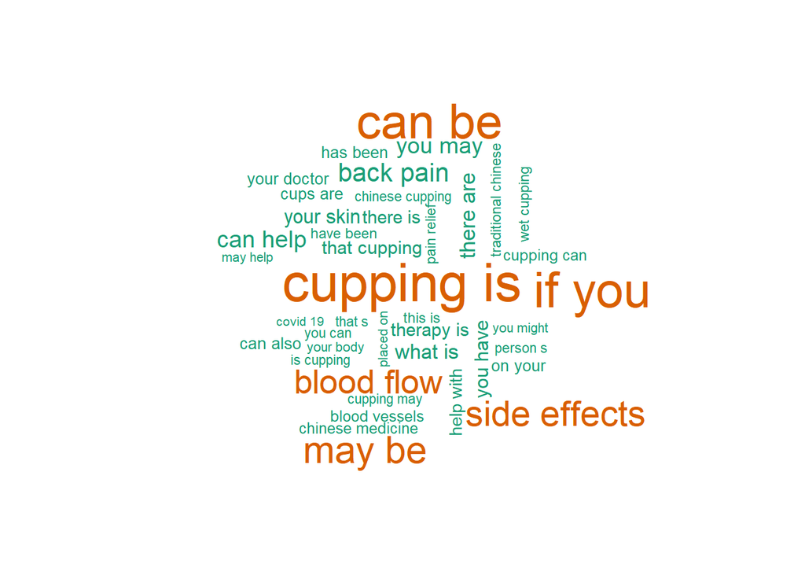

```r
wordcloud(names(freqCupping), freqCupping,
          min.freq=80,colors=brewer.pal(3,'Dark2'))
```

The above word cloud is for cupping therapy services.

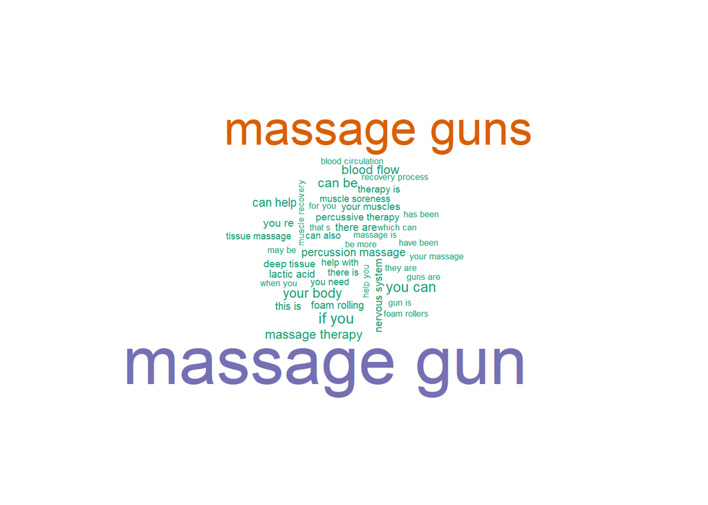

```r
wordcloud(names(freqMassageGun), freqMassageGun,
          min.freq=80,colors=brewer.pal(3,'Dark2'))
```

The above word cloud is for the massage gun services bigram word pairings in our documents on that category.

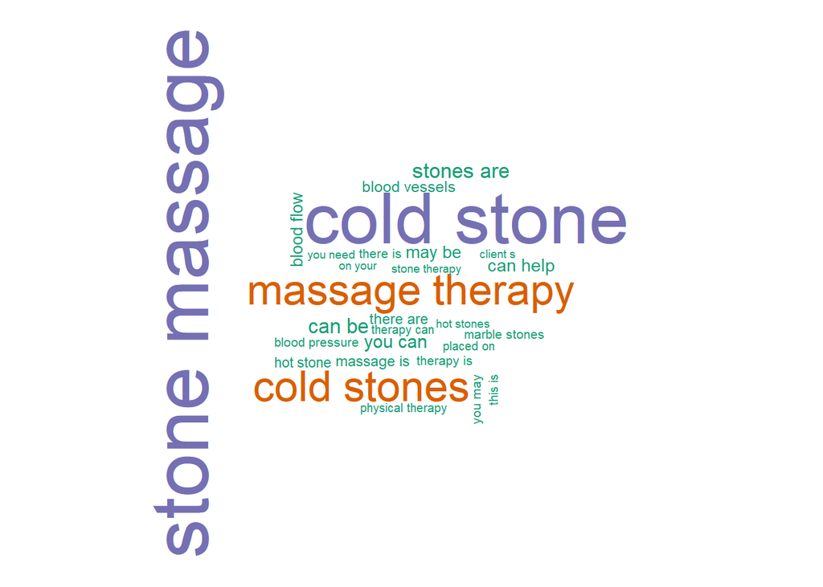

```r
wordcloud(names(freqColdStone), freqColdStone,
          min.freq=80,colors=brewer.pal(3,'Dark2'))
```

This last word cloud above is for cold stone massage therapy bigram word pairs in the documents on cold stone therapy benefits and contraindications.

Moving on, now that we have the non-professional category and our seven categories of legit healthcare recommended categories for users to input. We will need to get a medical services category with more documents, and differentiate between the benefits and contraindications for the other modalities, such as massage therapy, cold stone massage, and cupping therapy.